# Compare GR and RNAP2 Occupancy for GSE95632

Mengyuan Kan (mengykan@upenn.edu)

03 December, 2018

Compare differntial binding peaks of GR and RNAP2.

**User-defined variables** for files and paths:

```r
project_name="GSE95632"
tissue="ASM"
cond0="EtOH"
cond1="dex"
#out_dir="C:/Users/mengykan/Dropbox/UPenn/Research/ChIPSeq/GSE95632/comparisons"
#GR_peak_fn <- 'C:/Users/mengykan/Dropbox/UPenn/Research/ChIPSeq/GSE95632/GSE95632_diffbind_out/GSE95632_GR_dex_vs_GR_EtOH_sig_diffbind_results.csv'
#RNAP2_peak_fn <- 'C:/Users/mengykan/Dropbox/UPenn/Research/ChIPSeq/GSE95632/GSE95632_diffbind_out/GSE95632_RNAP2_dex_vs_RNAP2_EtOH_sig_diffbind_results.csv'
out_dir='/home/mengykan/Projects/GSE95632/comparisons'
GR_peak_fn <- '/home/mengykan/Projects/GSE95632/GSE95632_diffbind_out/GSE95632_GR_dex_vs_GR_EtOH_sig_diffbind_results.csv'
RNAP2_peak_fn <- '/home/mengykan/Projects/GSE95632/GSE95632_diffbind_out/GSE95632_RNAP2_dex_vs_RNAP2_EtOH_sig_diffbind_results.csv'
```

```
## Output file: /home/mengykan/Projects/GSE95632/comparisons/GSE95632_ASM_dex_vs_EtOH.GR_RNAP2.txt
```

**User-defined variables** for annotation libraries:

```r
annoDb_name='EnsDb.Hsapiens.v79'
txdb_name='TxDb.Hsapiens.UCSC.hg38.knownGene'
```

**User-defined variables** filterations:

- Fold.GR: include GR peaks with an absolute fold change > Fold.GR
- Fold.RNAP2: include RNAP2 peaks with an absolute fold change > Fold.RNAP2
- GENEBIOTYPE: include genes of the following types (antisense, lincRNA, LRG_gene, miRNA, protein_coding, snoRNA, TEC)

```r
GENEBIOTYPE="protein_coding"
```

Load libraries

```r
library(annoDb_name,character.only = TRUE)
library(txdb_name,character.only = TRUE)
library(dplyr)
library(limma)
library(ChIPseeker)
library(ggplot2)
library(RColorBrewer)
library(pander)
options(width = 1000)
```

Define that GR binding regions are located within 10kb upstream and 3kb downstream of the gene transcription start site. Define RNA polymerase II binding regions are located within +/- 3kb of the gene transcription start site.

### Genes with both GR and RNAP2 peaks

[output not shown]

*A2M*, *ABHD15*, *ABLIM3*, *ACKR2*, *ACTC1*, *ACVRL1*, *ADAM12*, *ADAM19*, *ADAM33*, *ADAMTS15*, *ADAMTS6*, *ADCK4*, *AFAP1L1*, *AGO2*, *AGTRAP*, *AHCYL1*, *AHDC1*, *AKAP2*, *AKR1D1*, *ALCAM*, *ALDH1B1*, *ALOX15B*, *AMER1*, *ANGPTL4*, *ANPEP*, *ANXA2*, *ANXA5*, *AOX1*, *AP3D1*, *APCDD1L*, *APOLD1*, *APPL2*, *APRT*, *ARHGAP22*, *ARMC8*, *ARNTL2*, *ASB1*, *ATP13A2*, *ATP1A1*, *ATP2B3*, *ATP6V1F*, *BBS10*, *BCKDHA*, *BCL3*, *BGN*, *BHLHE40*, *BICC1*, *BICD1*, *BLID*, *BLOC1S1*, *BNC2*, *BTBD2*, *C10orf10*, *C11orf68*, *C12orf75*, *C19orf35*, *C20orf96*, *C6orf1*, *C8orf58*, *C9*, *C9orf47*, *C9orf50*, *CAMK2N1*, *CARNS1*, *CASP6*, *CASS4*, *CAV1*, *CCDC40*, *CCDC85B*, *CCL2*, *CCND1*, *CCRN4L*, *CD109*, *CD3EAP*, *CD44*, *CD63*, *CDK17*, *CDKN1B*, *CDR2L*, *CEBPB*, *CEBPG*, *CEMIP*, *CHCHD4*, *CHD9*, *CIART*, *CIRBP*, *CITED2*, *CLASRP*, *CLCNKA*, *CLDN6*, *CLIC4*, *CMIP*, *CNN1*, *CNTRL*, *COL16A1*, *COL1A1*, *COL3A1*, *COL5A3*, *CORO2B*, *CPED1*, *CRABP2*, *CRACR2B*, *CREB3*, *CREB3L2*, *CRISPLD2*, *CROT*, *CRYAB*, *CSDC2*, *CSGALNACT2*, *CSRP2*, *CST3*, *CTDSPL*, *CTGF*, *CXXC5*, *CYB5D1*, *DAO*, *DDIT4*, *DDX47*, *DECR1*, *DHRS3*, *DIXDC1*, *DKK3*, *DLX2*, *DNLZ*, *DOT1L*, *DRAM1*, *DRAP1*, *DTX4*, *DUSP1*, *DUSP5*, *DUSP6*, *DVL1*, *EDN1*, *EEF1A1*, *EEF2K*, *EFHC1*, *EGFR*, *EGR1*, *EGR3*, *ELF1*, *ELMSAN1*, *ELN*, *ENC1*, *ERCC1*, *ERCC2*, *ERRFI1*, *ETV4*, *EVA1C*, *EXT1*, *F10*, *F2R*, *F3*, *FAM180A*, *FAM53A*, *FAM71E2*, *FAM83G*, *FARP1*, *FBXO3*, *FBXO32*, *FGD4*, *FGF2*, *FGF5*, *FIBCD1*, *FIBP*, *FKBP5*, *FLNC*, *FLRT2*, *FOS*, *FOSB*, *FOSL1*, *FOXC1*, *FOXF1*, *FOXO1*, *FOXO3*, *FOXP1*, *FSCN2*, *FSTL1*, *FTH1*, *FURIN*, *FUT4*, *GALNT6*, *GANC*, *GATA6*, *GEM*, *GGT5*, *GNB4*, *GNG11*, *GPR108*, *GPR133*, *GPR135*, *GPR153*, *GREM2*, *GSTO2*, *GXYLT2*, *GYPC*, *HAUS7*, *HBEGF*, *HCFC1R1*, *HEG1*, *HES1*, *HEXB*, *HIPK2*, *HIST1H2BC*, *HIVEP1*, *HMGA1*, *HMMR*, *HNRNPUL1*, *HOOK2*, *HR*, *HS3ST3B1*, *HSD17B4*, *HSPA8*, *HSPB1*, *HSPB2*, *HSPB7*, *ID2*, *ID3*, *IDE*, *IFITM10*, *IGF2BP3*, *IGFBP3*, *IKBKE*, *IL11*, *IL16*, *IL17RC*, *IL6*, *IL6ST*, *INPP5A*, *IRAK1*, *IRAK3*, *IRF2BPL*, *ITGA3*, *ITGA5*, *ITGA7*, *ITGB8*, *ITGBL1*, *ITPKC*, *JADE2*, *JOSD2*, *JPH2*, *JUN*, *JUNB*, *KAT6B*, *KAZALD1*, *KCNE4*, *KCTD11*, *KCTD12*, *KCTD3*, *KDF1*, *KDM6B*, *KIAA0319L*, *KIAA0408*, *KIAA0922*, *KITLG*, *KLF15*, *KLF4*, *KLF6*, *KLF9*, *KLHL26*, *KRR1*, *LAMA2*, *LAMB1*, *LARP6*, *LCA5*, *LDHA*, *LIF*, *LOXL1*, *LPCAT2*, *LPXN*, *LRCH2*, *LRP1*, *LRRC32*, *LRRC8C*, *LRRC8D*, *LTBP2*, *MAFK*, *MAP1LC3B*, *MAP2K3*, *MAP3K6*, *MARCH4*, *MARCKS*, *MBNL2*, *MEDAG*, *METTL7A*, *MIDN*, *MISP*, *MKLN1*, *MLXIP*, *MMP14*, *MMP19*, *MND1*, *MRC2*, *MRPL50*, *MSANTD3*, *MSC*, *MSI2*, *MT1E*, *MT1M*, *MT1X*, *MT2A*, *MTERF2*, *MTFP1*, *MXRA8*, *MYEOV*, *MYH10*, *MYLPF*, *MYO1D*, *NAALADL2*, *NAB2*, *NAGS*, *NANOS3*, *NAT14*, *NAV1*, *NBN*, *NCDN*, *NCKIPSD*, *NEDD4*, *NFATC1*, *NFATC4*, *NFE2L1*, *NFIC*, *NFKBIA*, *NID1*, *NPAS1*, *NPEPL1*, *NR3C2*, *NT5DC2*, *NT5DC3*, *NT5E*, *NUDCD2*, *NUDT17*, *NYAP1*, *OLFML3*, *PARP4*, *PDCD1LG2*, *PDGFRB*, *PDHA1*, *PDK4*, *PER1*, *PHF20*, *PHLDA3*, *PICALM*, *PIWIL4*, *PKM*, *PLAU*, *PLAUR*, *PLEKHA2*, *PLEKHG2*, *PLOD2*, *PM20D2*, *PNPLA2*, *PPM1B*, *PPP1R13L*, *PPP1R15A*, *PRDX6*, *PRRG4*, *PSD4*, *PSG5*, *PTGIS*, *PTPN1*, *PTRF*, *PYGB*, *PYY*, *QSOX1*, *RAB32*, *RAB3A*, *RAI14*, *RARG*, *RASD1*, *RASSF2*, *RASSF4*, *RDH10*, *RDH5*, *RECK*, *RELT*, *REV3L*, *RFESD*, *RGL1*, *RGMB*, *RGS2*, *RHOB*, *RIPK2*, *RNF103*, *RNF215*, *ROCK1*, *ROR1*, *RPL26L1*, *RPL3*, *RPL7*, *RRM2*, *RUNX1*, *S100A10*, *S1PR1*, *S1PR3*, *SAMD11*, *SAP30*, *SASH1*, *SAT1*, *SCRN1*, *SDC4*, *SDCBP2*, *SEC22B*, *SEMA7A*, *SEPT11*, *SERPINE2*, *SERPING1*, *SERTAD1*, *SGIP1*, *SH3PXD2A*, *SIK2*, *SKIL*, *SLC16A6*, *SLC19A2*, *SLC4A8*, *SMAD7*, *SMG9*, *SMIM3*, *SMIM4*, *SMURF2*, *SMYD2*, *SNAI1*, *SOCS3*, *SOCS5*, *SOX4*, *SPARC*, *SPARCL1*, *SPCS3*, *SPDL1*, *SPTBN1*, *SRPX*, *SSC5D*, *SSH1*, *ST3GAL1*, *ST3GAL4*, *ST3GAL5*, *STAMBPL1*, *STAT3*, *STAT6*, *STOM*, *STX10*, *STXBP6*, *SYNJ2*, *SYT8*, *TACC1*, *TAF5L*, *TAF8*, *TAGLN*, *TBC1D1*, *TBC1D10B*, *TBC1D22B*, *TBC1D23*, *TBX3*, *TBXAS1*, *TCF21*, *TENM4*, *TGFB1*, *TGFBI*, *TGFBR2*, *THBS1*, *THOC6*, *TIMP1*, *TIMP3*, *TIPARP*, *TLN1*, *TMEM150A*, *TMEM158*, *TMEM160*, *TMEM190*, *TMEM194A*, *TMEM217*, *TMEM43*, *TMEM47*, *TMEM59L*, *TMEM87A*, *TMEM88*, *TMEM91*, *TMEM95*, *TMSB10*, *TNC*, *TNFAIP8L3*, *TNFRSF11B*, *TNFRSF12A*, *TNKS1BP1*, *TNS2*, *TPM1*, *TPRG1*, *TRABD2A*, *TRAF3IP2*, *TRIB1*, *TRIM45*, *TRIM55*, *TRIM8*, *TRIO*, *TRIP10*, *TTC39B*, *TTYH3*, *TXNIP*, *UACA*, *UBC*, *UBE2E2*, *UBE2L6*, *UPK2*, *URB2*, *USP39*, *USP46*, *USP53*, *UST*, *VCL*, *VEGFA*, *VEGFC*, *VGLL3*, *VIM*, *VIMP*, *VPS37C*, *WBP1L*, *WBP4*, *WIPI1*, *WISP1*, *WLS*, *WNT5A*, *WSB2*, *XPO1*, *YWHAQ*, *ZBTB46*, *ZC3H12C*, *ZDHHC9*, *ZFHX3*, *ZFP36*, *ZFP36L2*, *ZFP91*, *ZMYND8*, *ZNF189*, *ZNF22*, *ZNF281*, *ZNF608*, *ZNF622*, *ZNF674*, *ZNF710*, *ZNF850* and *ZSWIM4*

### Distribution of GR and RNAP2 peaks near promoter regions

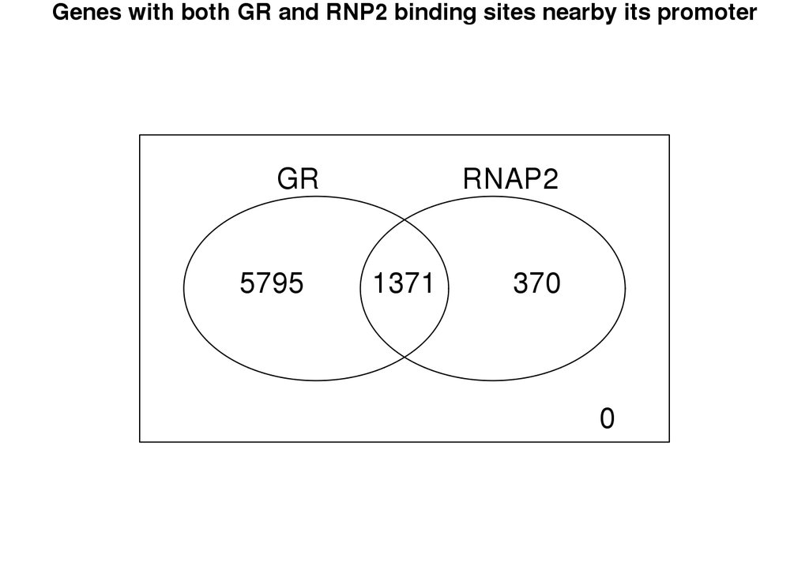

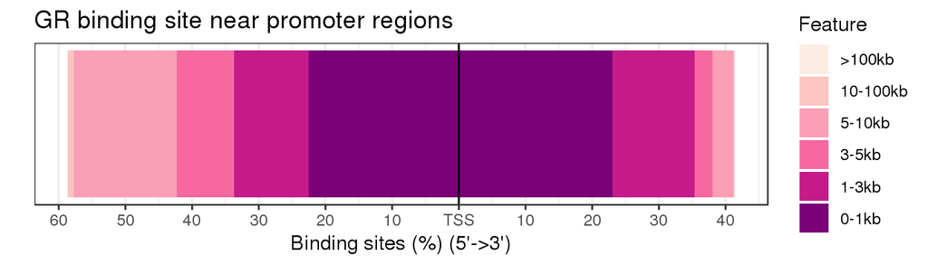

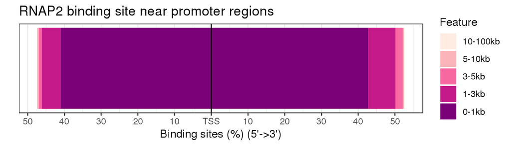

**R version 3.4.3 (2017-11-30)**

**Platform:** x86_64-redhat-linux-gnu (64-bit)

**locale:** *LC_CTYPE=en_US.UTF-8*, *LC_NUMERIC=C*, *LC_TIME=en_US.UTF-8*, *LC_COLLATE=en_US.UTF-8*, *LC_MONETARY=en_US.UTF-8*, *LC_MESSAGES=en_US.UTF-8*, *LC_PAPER=en_US.UTF-8*, *LC_NAME=C*, *LC_ADDRESS=C*, *LC_TELEPHONE=C*, *LC_MEASUREMENT=en_US.UTF-8* and *LC_IDENTIFICATION=C*

**attached base packages:** *stats4*, *parallel*, *stats*, *graphics*, *grDevices*, *utils*, *datasets*, *methods* and *base*

**other attached packages:** *bindrcpp(v.0.2.2)*, *pander(v.0.6.1)*, *RColorBrewer(v.1.1-2)*, *ggplot2(v.3.0.0)*, *ChIPseeker(v.1.14.2)*, *limma(v.3.34.9)*, *dplyr(v.0.7.6)*, *TxDb.Hsapiens.UCSC.hg38.knownGene(v.3.4.0)*, *EnsDb.Hsapiens.v79(v.2.99.0)*, *ensembldb(v.2.2.2)*, *AnnotationFilter(v.1.2.0)*, *GenomicFeatures(v.1.30.3)*, *AnnotationDbi(v.1.40.0)*, *Biobase(v.2.38.0)*, *GenomicRanges(v.1.30.3)*, *GenomeInfoDb(v.1.14.0)*, *IRanges(v.2.12.0)*, *S4Vectors(v.0.16.0)*, *BiocGenerics(v.0.24.0)* and *rmarkdown(v.1.9)*

**loaded via a namespace (and not attached):** *ProtGenerics(v.1.10.0)*, *bitops(v.1.0-6)*, *matrixStats(v.0.54.0)*, *bit64(v.0.9-7)*, *progress(v.1.1.2)*, *httr(v.1.3.1)*, *UpSetR(v.1.3.3)*, *rprojroot(v.1.3-2)*, *tools(v.3.4.3)*, *backports(v.1.1.2)*, *R6(v.2.2.2)*, *KernSmooth(v.2.23-15)*, *DBI(v.0.8)*, *lazyeval(v.0.2.1)*, *colorspace(v.1.3-2)*, *withr(v.2.1.2)*, *tidyselect(v.0.2.4)*, *gridExtra(v.2.3)*, *prettyunits(v.1.0.2)*, *RMySQL(v.0.10.15)*, *bit(v.1.1-12)*, *curl(v.3.1)*, *compiler(v.3.4.3)*, *DelayedArray(v.0.4.1)*, *rtracklayer(v.1.38.3)*, *caTools(v.1.17.1)*, *scales(v.1.0.0)*, *stringr(v.1.3.0)*, *digest(v.0.6.16)*, *Rsamtools(v.1.30.0)*, *DOSE(v.3.4.0)*, *XVector(v.0.18.0)*, *pkgconfig(v.2.0.2)*, *htmltools(v.0.3.6)*, *plotrix(v.3.7-3)*, *rlang(v.0.2.2)*, *RSQLite(v.2.0)*, *BiocInstaller(v.1.28.0)*, *shiny(v.1.1.0)*, *TxDb.Hsapiens.UCSC.hg19.knownGene(v.3.2.2)*, *bindr(v.0.1.1)*, *gtools(v.3.5.0)*, *BiocParallel(v.1.12.0)*, *GOSemSim(v.2.4.1)*, *RCurl(v.1.95-4.10)*, *magrittr(v.1.5)*, *GO.db(v.3.5.0)*, *GenomeInfoDbData(v.1.0.0)*, *Matrix(v.1.2-12)*, *Rcpp(v.0.12.18)*, *munsell(v.0.5.0)*, *stringi(v.1.2.3)*, *yaml(v.2.1.18)*, *SummarizedExperiment(v.1.8.1)*, *zlibbioc(v.1.24.0)*, *gplots(v.3.0.1)*, *plyr(v.1.8.4)*, *qvalue(v.2.10.0)*, *AnnotationHub(v.2.10.1)*, *grid(v.3.4.3)*, *blob(v.1.1.1)*, *gdata(v.2.18.0)*, *promises(v.1.0.1)*, *DO.db(v.2.9)*, *lattice(v.0.20-35)*, *Biostrings(v.2.46.0)*, *splines(v.3.4.3)*, *knitr(v.1.20)*, *pillar(v.1.2.1)*, *fgsea(v.1.4.1)*, *igraph(v.1.2.2)*, *boot(v.1.3-20)*, *reshape2(v.1.4.3)*, *biomaRt(v.2.34.2)*, *fastmatch(v.1.1-0)*, *XML(v.3.98-1.10)*, *glue(v.1.3.0)*, *evaluate(v.0.10.1)*, *data.table(v.1.11.4)*, *httpuv(v.1.4.3)*, *gtable(v.0.2.0)*, *purrr(v.0.2.5)*, *assertthat(v.0.2.0)*, *gridBase(v.0.4-7)*, *mime(v.0.5)*, *xtable(v.1.8-2)*, *later(v.0.7.3)*, *tibble(v.1.4.2)*, *rvcheck(v.0.1.0)*, *GenomicAlignments(v.1.14.2)*, *memoise(v.1.1.0)* and *interactiveDisplayBase(v.1.16.0)*